# Tidy Tuesday 2021 Week 41

2021/10/05

[TidyTuesday](https://github.com/rfordatascience/tidytuesday) week 41: [Registered Nurses](https://github.com/rfordatascience/tidytuesday/tree/master/data/2021/2021-10-05), data from [Data.World](https://data.world/zendoll27/registered-nursing-labor-stats-1998-2020).

```r
library(tidyverse)
library(janitor)
library(ggtext)
library(scales)
library(geofacet)
library(colorspace)
library(biscale)
library(cowplot)
```

```r
nurses <- readr::read_csv('https://raw.githubusercontent.com/rfordatascience/tidytuesday/master/data/2021/2021-10-05/nurses.csv') %>% clean_names()
```

```r
range(nurses$year)
```

```
[1] 1998 2020
```

### Tile map

- shared on [Twitter](https://twitter.com/leeolney3/status/1445196349889290241)

```r
nurses$st <- state.abb[match(nurses$state, state.name)]

df20 = nurses %>% filter(year==2020) %>%
  mutate(st=ifelse(state=="District of Columbia","DC",st)) %>%
  mutate(st=ifelse(state=="Puerto Rico","PR",st)) %>%
  drop_na(st)
```

```r
df1 = df20 %>%
  select(state, st, year, total_employed_rn, hourly_wage_median) %>%
  bi_class(x=hourly_wage_median, y=total_employed_rn, style="quantile",dim=3)
```

```r
create_gradient_state_tile_map <- function(state, value, title, subtitle, caption, legend_title, state_grid='us_state_with_DC_PR_grid2') {

  df <- as.tibble(data.frame(state, value))

  fig <- df %>%
    mutate(x = 1) %>%
    mutate(label_y = .5) %>%
    mutate(label_x = 1) %>%
    ggplot()+
    geom_bar(mapping=aes(x=x, fill=value), width=.4)  +
    facet_geo(~ state, grid=state_grid) +
    labs(title=title, subtitle=subtitle, caption=caption) +
    geom_text(aes(x=label_x, y=label_y, label=state, color=value),size=3, show.legend=F, family="sans")

  return(fig)
}
```

```r
# excl. Guam and Virgin Islands
p1 = create_gradient_state_tile_map(df1$st, df1$bi_class,
                                    title='US-based Registered Nurses Employment and Wage in 2020', legend_title = "",
                                    subtitle="<span style = 'color:#012a4a;'><b>Total employed registered nurses</b></span> and <span style = 'color:#012a4a;'><b>median hourly wage</b></span>, by US state\n",
                               caption="Note: Data from Guam and Virgin Islands are not presented<br>#TidyTuesday Week 41 | Data from Data.World") +
  bi_scale_fill(pal="DkCyan",dim=3, guide="none") +
  scale_color_manual(values=c("grey10","grey10","white","white","white","white","white","white","white")) +
  theme_void(base_size=10, base_family = "sans") +
  theme(strip.text.x = element_blank(),
        plot.margin = unit(c(.5,4,.5,2), "cm"),
        plot.title=element_text(size=14, face="bold", color="#012a4a"),
        plot.subtitle=element_markdown(size=8, color="#011c31", margin=margin(t=5,b=18)),
        legend.title=element_text(size=9),
        plot.caption = element_markdown(size=5.6, color="#011c31",margin=margin(t=30), lineheight=1.5, hjust=0)) +
  guides(fill = guide_colorbar(title="Count",
                              title.position = "top",
                              barwidth = unit(.5, "lines"),
                              barheight = unit(10, "lines")))
```

```r
p2 = bi_legend(pal = "DkCyan",
            dim = 3,
            ylab = "Total employed",
            xlab = "Median hourly wage",
            size = 2.5) +
  theme(panel.border = element_blank(),
        axis.text = element_blank(),
        axis.title.x = element_text(size = 6, family="sans",
                                    color = "#011c31", margin=margin(t=-5)),
        axis.title.y = element_text(size = 6, family="sans",
                                    color = "#011c31", margin=margin(r=-5)),
        legend.text = element_text(size = 6),
        plot.background = element_blank(),
        legend.text.align = 0)
```

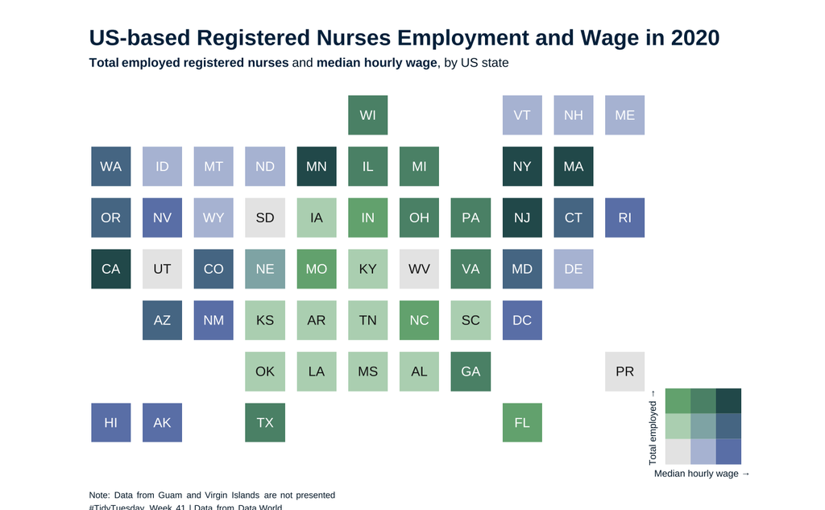

```r
ggdraw() +
  draw_plot(p1, 0, 0, 1, 1) +
  draw_plot(p2, 0.72, 0.04, 0.25, 0.25)
```

AlT text: Bivariate heatmap of US-based registered nurses’ median hourly rate and total employment by state (excluding Guam and Virgin Island). The visualization shows that in comparison to other states: Utah, South Dakota, West Virginia and Puerto Rico have the least total registered nurses employment and lowest median hourly rate. California, Minnesota, Massachusetts, New York, and New Jersey have the most total employment and highest median hourly rate compared to the other states.

### Tile map v2

- add labels for median hourly rage and total employment

```r
# bivariate palette reference: https://nowosad.github.io/post/cbc-bp2/
library(pals)
#brewer.seqseq2()
bi_pal <- bi_pal_manual(val_1_1 = "#f3f3f3", val_1_2 = "#b4d3e1", val_1_3 = "#509dc2",
                        val_2_1 = "#f3e6b3", val_2_2 = "#b3b3b3",val_2_3 = "#376387",
                        val_3_1 = "#f3b300", val_3_2 = "#b36600",val_3_3 = "#000000")
# label colors
df2 = df1 %>%
  mutate(col=case_when(str_detect(bi_class,"3")~"white",TRUE~"black")) %>%
  mutate(col=case_when(bi_class=="3-1"~"black",TRUE~col))
```

```r
p1b = df2 %>%
  ggplot() +
  geom_rect(aes(fill=bi_class), xmin=-1, xmax=1, ymin=-1, ymax=1, color="white", show.legend = F) +
  geom_richtext(aes(color=col, label=glue::glue("<span style='font-size: 11px;'>{st}</span><br>{dollar(hourly_wage_median)}<br>{round(total_employed_rn/1000,1)}K")),
                x=0.5, y=0.45, size=1.5, hjust=.5, fill=NA, label.color=NA, show.legend = F) +
  scale_color_identity() +
  facet_geo(vars(st), grid=us_state_with_DC_PR_grid2) +
  bi_scale_fill(pal=bi_pal, dim=3, guide="none") +
  theme_void(base_size = 9) +
  theme(strip.text = element_blank(),
        plot.margin = unit(c(.5, 3.2, .5, 2.5), "cm"),
        plot.title=element_markdown(face="bold"),
        plot.subtitle=element_markdown(margin=margin(t=4, b=15)),
        plot.caption=element_text(size=6, hjust=0, margin=margin(b=0, t=30))) +
  labs(title="2020 US-based Registered Nurses Wage and Employment",
       subtitle="Median hourly wage and total employed, by state",
       caption="Note: Data from Guam and Virgin Islands are not presented\nData source: Data.World")

p2b = bi_legend(pal =  bi_pal,
            dim = 3,
            ylab = "Total employed",
            xlab = "Median hourly wage",
            size = 2.5) +
  theme(panel.border = element_blank(),
        axis.text = element_blank(),
        axis.title.x = element_text(size = 6, family="sans",
                                    color = "#011c31", margin=margin(t=-5)),
        axis.title.y = element_text(size = 6, family="sans",
                                    color = "#011c31", margin=margin(r=-5)),
        legend.text = element_text(size = 6),
        plot.background = element_blank(),
        legend.text.align = 0)
```

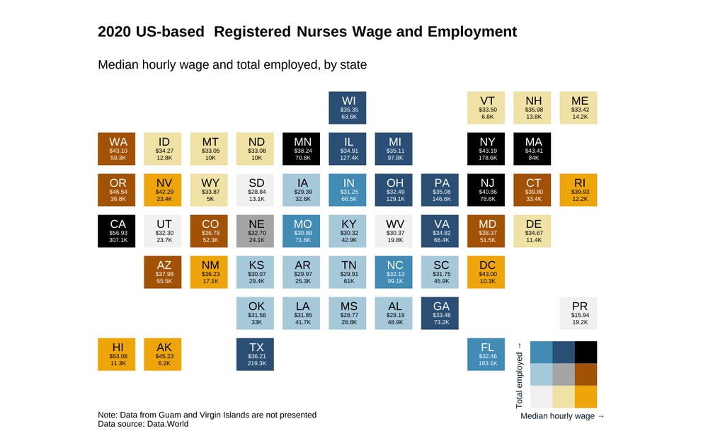

```r
ggdraw() +
  draw_plot(p1b, 0, 0, 1, 1) +
  draw_plot(p2b, 0.645, 0.04, 0.25, 0.25)
```

### Western region table

```r
library(gt)
library(gtExtras)
library(usmap)
library(patchwork)
```

```r
nurses$st = state.abb[match(nurses$state, state.name)]

tab1 = df20 %>%
  filter(st %in% .west_region) %>%
  mutate(division= case_when(st %in% .mountain ~ "Mountain division",
                             st %in% .pacific ~ "Pacific division")) %>%
  #group_by(state) %>%
  #mutate(ratio=total_employed_rn/total_employed_healthcare_state_aggregate) %>%
  #ungroup() %>%
  select(state,division,  annual_salary_avg, hourly_wage_avg,wage_salary_standard_error_percent,
         total_employed_rn,total_employed_healthcare_state_aggregate,yearly_total_employed_state_aggregate,
         location_quotient) %>%
  arrange(desc(annual_salary_avg))
```

```r
tab1 %>%
  gt(groupname_col = "division") %>%
  tab_header(title = "WESTERN U.S. REGISTERED NURSES 2020") %>%
  tab_source_note(source_note="Data source: Data.World") %>%
  cols_label(
    annual_salary_avg = html("Annual ($)"),
    hourly_wage_avg = html("Hourly ($)"),
    wage_salary_standard_error_percent = html("SE (%)"),
    total_employed_rn = html("RN"),
    total_employed_healthcare_state_aggregate=html("Healthcare"),
    yearly_total_employed_state_aggregate = html("Yearly"),
    location_quotient=html("Quotient"),
    state=html("State"),
  ) %>%
  tab_spanner(
    label = "Total Employed",
    columns = total_employed_rn:yearly_total_employed_state_aggregate
  ) %>%
  tab_spanner(
    label = "Salary/Wage",
    columns = annual_salary_avg:wage_salary_standard_error_percent
  ) %>%
  tab_spanner(
    label = "Location",
    columns = location_quotient
  ) %>%
  tab_options(table.font.size = "14px",
              heading.title.font.size = "18px",column_labels.border.bottom.color = "grey",
              data_row.padding = px(4),
              heading.padding = px(10),
              ) %>%
  gt_hulk_col_numeric(location_quotient) %>%
  #gt_hulk_col_numeric(hourly_wage_avg) %>%
  gt_hulk_col_numeric(annual_salary_avg) %>%
  gt_hulk_col_numeric(total_employed_rn) %>%
  cols_align(
    align = "center",
    columns = annual_salary_avg:location_quotient
  ) %>%
  cols_width(annual_salary_avg:location_quotient ~ px(80)) %>%
  cols_width(state ~ px(110)) %>%
  fmt_number(annual_salary_avg:location_quotient, use_seps = T, drop_trailing_zeros = T) %>%
  tab_footnote(
    footnote = md("Total employed registered nurses"),
    locations = cells_column_labels(columns = total_employed_rn)
  ) %>%
  tab_footnote(
    footnote = md("Total employed healthcare, state aggregate"),
    locations = cells_column_labels(columns = total_employed_healthcare_state_aggregate)
  ) %>%
  tab_footnote(
    footnote = md("Yearly total employed, state aggregte"),
    locations = cells_column_labels(columns = yearly_total_employed_state_aggregate)
  ) %>%
  tab_style(
    style = list(
      cell_text(font=google_font(
        name = "Libre Franklin"), weight='800',align = "left",color='#203B46')),
    locations = cells_title(groups = "title")
  ) %>%
  tab_style(style = cell_text(font = google_font("Source Sans Pro"),
            weight = 400), locations = cells_body()) %>%
  tab_style(style = cell_text(size = px(12.5), color = "grey30",
        font = google_font("Source Sans Pro"), transform = "uppercase"),
        locations = cells_column_labels(everything())) %>%
  tab_style(style = cell_text(size = px(12.5), color = "grey30",
        font = google_font("Source Sans Pro"), transform = "uppercase"),
        locations = cells_column_spanners()) %>%
  tab_style(style = cell_text(size = px(13), color = "grey20",
        font = google_font("Source Sans Pro"), style="italic"),
        locations = cells_footnotes()) %>%
  tab_style(style = cell_text(size = px(13), color = "grey20",
        font = google_font("Source Sans Pro")),
        locations = cells_source_notes()) %>%
  tab_style(style = cell_text(color = "#203B46",
        font = google_font("Source Sans Pro"), weight=600, transform = "uppercase"),
        locations = cells_row_groups())
```

WESTERN U.S. REGISTERED NURSES 2020

| State | Salary/Wage Annual ($) | Salary/Wage Hourly ($) | Salary/Wage SE (%) | Total Employed RN<sup>1</sup> | Total Employed Healthcare<sup>2</sup> | Total Employed Yearly<sup>3</sup> | Location Quotient |
| --- | --- | --- | --- | --- | --- | --- | --- |
| Pacific division |  |  |  |  |  |  |  |
| California | 120,560 | 57.96 | 1 | 307,060 | 844,740 | 16,430,660 | 0.87 |
| Hawaii | 104,830 | 50.4 | 1.9 | 11,260 | 31,410 | 574,010 | 0.91 |
| Oregon | 96,230 | 46.27 | 1 | 36,840 | 100,230 | 1,806,950 | 0.95 |
| Alaska | 95,270 | 45.81 | 1.4 | 6,240 | 17,730 | 296,300 | 0.98 |
| Washington | 91,310 | 43.9 | 0.9 | 59,300 | 171,850 | 3,195,200 | 0.86 |
| Mountain division |  |  |  |  |  |  |  |
| Nevada | 89,750 | 43.15 | 1.9 | 23,420 | 67,590 | 1,250,860 | 0.87 |
| Arizona | 80,380 | 38.64 | 0.9 | 55,520 | 171,010 | 2,835,110 | 0.91 |
| Colorado | 77,860 | 37.43 | 0.7 | 52,330 | 144,490 | 2,578,000 | 0.95 |
| New Mexico | 75,700 | 36.4 | 1.4 | 17,100 | 47,340 | 785,720 | 1.01 |
| Wyoming | 72,600 | 34.9 | 1.1 | 5,010 | 14,010 | 261,690 | 0.89 |
| Idaho | 71,640 | 34.44 | 0.9 | 12,800 | 40,750 | 718,820 | 0.83 |
| Montana | 70,530 | 33.91 | 1.2 | 9,980 | 29,770 | 455,450 | 1.02 |
| Utah | 70,370 | 33.83 | 0.9 | 23,690 | 72,300 | 1,489,020 | 0.74 |

Data source: Data.World  
<sup>*1*</sup> Total employed registered nurses <sup>*2*</sup> Total employed healthcare, state aggregate <sup>*3*</sup> Yearly total employed, state aggregte

### Northeast region table

```r
# gt_plt_bar_stack reference: https://github.com/BjnNowak/TidyTuesday/blob/main/SC_Nurse.R
bar_hourly = df20 %>% filter(st %in% .northeast_region) %>%
  group_by(state) %>%
  mutate(
    X25=round(hourly_25th_percentile),
    X50=round(hourly_wage_median),
    X75=round(hourly_75th_percentile)
    ) %>%
  arrange(-X75)%>%
  summarise(Hourly = list(c(X25,X50,X75)))

bar_annual = df20 %>% filter(st %in% .northeast_region) %>%
  group_by(state) %>%
  mutate(
    X25=round(annual_25th_percentile),
    X50=round(annual_salary_median),
    X75=round(annual_75th_percentile)
  )%>%
  arrange(-X75)%>%
  summarise(Annual = list(c(X25,X50,X75)))
```

```r
df20 %>% filter(st %in% .northeast_region) %>%
  left_join(bar_hourly) %>%
  left_join(bar_annual) %>%
  arrange(desc(annual_salary_avg)) %>%
  select(state, total_employed_rn, annual_salary_avg, Annual, hourly_wage_avg, Hourly) %>%
  gt() %>%
  gt_theme_538() %>%
  #gt_merge_stack(col1 = state, col2 = st) %>%
  gt_plt_dot(annual_salary_avg,state,palette = c("#6c757d", "#dee2e6")) %>%
  gt_plt_bar_stack(
    column=Annual, palette = c("#a4243b","#05668d","#d8973c"),
    position = 'stack', labels = c("1st quartile", "Median", "3rd quartile"),
    width = 60,trim=TRUE
  ) %>%
  gt_plt_bar_stack(
    column=Hourly, palette = c("#5f0f40","#e36414","#0f4c5c"),
    position = 'stack', labels = c("1st quartile", "Median", "3rd quartile"),
    width = 60,trim=TRUE
  ) %>%
  cols_label(
    total_employed_rn = html("Employment"),
    annual_salary_avg = html("Avg"),
    hourly_wage_avg = html("Avg")
    ) %>%
  tab_spanner(
    label = "Annual Salary ($)",
    columns = annual_salary_avg:Annual
  ) %>%
  tab_spanner(
    label = "Hourly Wage ($)",
    columns = hourly_wage_avg:Hourly
  ) %>%
  tab_style(
    style = list(cell_text(align = "center")),
    locations = cells_column_labels(columns=c(annual_salary_avg,hourly_wage_avg))
  ) %>%
  tab_style(
    style = list(cell_text(align = "left")),
    locations = cells_column_labels(columns=c(Annual,Hourly))
  ) %>%
  tab_style(
    style = list(
      cell_text(font=google_font(
        name = "Libre Franklin"), weight='800',align = "left",color='black')),
    locations = cells_title(groups = "title")
  ) %>%
  tab_options(data_row.padding = px(6),
              table.font.size = "14px",
              column_labels.font.size = "10.5px",
              heading.padding = px(5),
              column_labels.padding = px(8),
              source_notes.padding = px(14),
              ) %>%
  tab_header(title = "2020 U.S. Registered Nurses in the Northeast Region", subtitle="New York has the highest number of employed registered nurses, and Massachusetts has the highest average annual salary and hourly wage in 2020.") %>%
  tab_source_note(source_note="Data source: Data.World")
```

2020 U.S. Registered Nurses in the Northeast Region

New York has the highest number of employed registered nurses, and Massachusetts has the highest average annual salary and hourly wage in 2020.

state

Employment

Annual Salary ($)

Hourly Wage ($)

Avg

**1st quartile**||**Median**||**3rd quartile**

Avg

**1st quartile**||**Median**||**3rd quartile**

Massachusetts

84030

96250

[figure not shown]

46.27

New York

178550

89760

[figure not shown]

43.16

New Jersey

78590

85720

[figure not shown]

41.21

Connecticut

33400

84850

[figure not shown]

40.79

Rhode Island

12150

82790

[figure not shown]

39.81

New Hampshire

13840

75970

[figure not shown]

36.52

Pennsylvania

146640

74170

[figure not shown]

35.66

Vermont

6810

72140

[figure not shown]

34.68

Maine

14160

71040

[figure not shown]

34.16

Data source: Data.World

### Hourly wage difference between states

```r
c1 = nurses %>%
  mutate(st=ifelse(state=="District of Columbia","DC",st)) %>%
  drop_na(st) %>%
  select(year, state, hourly_wage_median, total_employed_rn)

c2 = c1 %>%
  group_by(year) %>%
  arrange(year,hourly_wage_median) %>%
  filter(hourly_wage_median==max(hourly_wage_median) | hourly_wage_median==min(hourly_wage_median))

c3 = anti_join(c1,c2)
```

```r
# years with largest and smallest difference
c2 %>% group_by(year) %>%
  mutate(diff= hourly_wage_median-lag(hourly_wage_median)) %>%
  drop_na() %>% ungroup() %>%
  filter(diff==max(diff)|diff==min(diff)) %>%
  select(year, diff)
```

| year | diff |
| --- | --- |
| 2000 | 9.68 |
| 2020 | 28.74 |

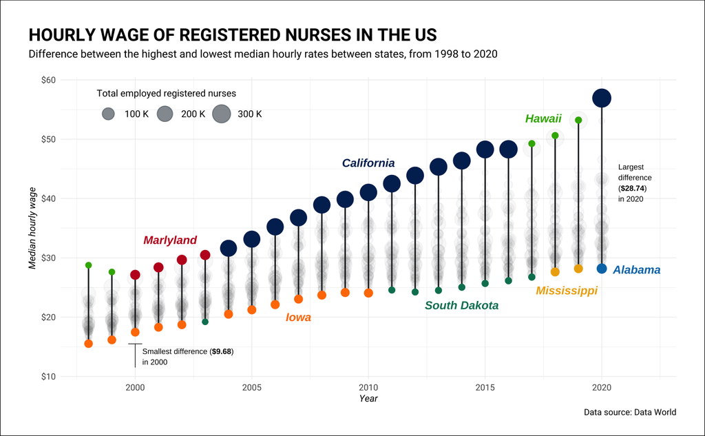

```r
# plot reference: https://twitter.com/maxwelco/status/1445857876614942722/photo/1
c2 %>%
  ggplot(aes(x=year, y=hourly_wage_median)) +
  geom_point(data=c3 , aes(size=total_employed_rn),
             color="#6c757d", alpha=.05) +
  geom_line(aes(group=year), color="#212529") +
  geom_point(aes(color=state, size=total_employed_rn)) +
  scale_color_manual(values=c("#0077b6","#01295f","#38b000","#ff7b00","#c00021","#EDAD08","#007f5f"), guide="none") +
  scale_x_continuous("Year",limits=c(1998, 2022)) +
  scale_y_continuous("Median hourly wage", labels=scales::dollar_format(), limits=c(10,60), breaks=seq(10,60,10), expand=c(0.01,0.01)) +
  scale_size("Total employed registered nurses",labels=scales::unit_format(unit = "K", scale = 1e-3)) +
  theme_minimal(base_size = 8, base_family = "Roboto Condensed") +
  theme(plot.background = element_rect(color="black"),
        panel.grid=element_line(size=.2),
        legend.direction = "horizontal",
        legend.position=c(.05,.9),
        legend.justification = "left",
        legend.title=element_text(size=7),
        legend.text=element_text(size=7),
        axis.title.y=element_text(size=7, margin=margin(r=3), face="italic"),
        axis.title.x=element_text(size=7, face="italic"),
        plot.title=element_text(size=13, face="bold"),
        plot.title.position = "plot",
        plot.margin = unit(c(.75, .75, .5, .75), "cm"),
        ) +
  annotate(geom="text", size=3, fontface="bold.italic",
           x=c(2014,2018.5, 2021.5, 2007, 2017.5,2010,2001.5), y=c(22,24.5,28,20,53.5,46,33),
           label=c("South Dakota","Mississippi","Alabama","Iowa","Hawaii","California","Marlyland"),
           color=c("#007f5f","#EDAD08","#0077b6","#ff7b00","#38b000","#01295f","#c00021")) +
  guides(size=guide_legend(title.position = "top",override.aes = list(color = "#6c757d", alpha=.5))) +
  labs(title=str_to_upper("Hourly wage of Registered Nurses in the US"),
       subtitle="Difference between the highest and lowest median hourly rates between states, from 1998 to 2020\n",
       caption="Data source: Data World") +
  annotate(geom="segment", size=.2, x=c(2000,1999.7), xend=c(2000,2000.3), y=c(11.5,15.5), yend=c(15.5,15.5)) +
  annotate(geom="richtext", fill = NA, label.color = NA, size=2, lineheight=1.4, hjust=0, x=c(2000.1,2020.5), y=c(13.2,42.5),
           label=c("Smallest difference (**$9.68**)<br>in 2000","Largest<br>difference<br>(**$28.74**)<br>in 2020"))
```

### Western region: annual salary

```r
p3 = df20 %>% filter(st %in% .west_region) %>%
  select(state, annual_salary_median,annual_10th_percentile,annual_90th_percentile,
         annual_25th_percentile,annual_75th_percentile) %>%
  arrange(desc(annual_salary_median)) %>%
  mutate(state=fct_rev(fct_inorder(state))) %>%
  ggplot() +
  geom_segment(aes(y=state, yend=state, x=annual_10th_percentile, xend=annual_90th_percentile),
               linetype="dotted", color="white") +
  geom_segment(aes(y=state, yend=state, x=annual_25th_percentile, xend=annual_75th_percentile), color="white", size=.8) +
  geom_point(aes(y=state, x=annual_salary_median), size=2.3, color="white") +
  geom_point(aes(y=state, x=annual_25th_percentile), size=3, color="white", shape="|") +
  geom_point(aes(y=state, x=annual_75th_percentile), size=3, color="white", shape="|") +
  geom_point(aes(y=state, x=annual_10th_percentile), size=2, color="white", shape="|") +
  geom_point(aes(y=state, x=annual_90th_percentile), size=2, color="white", shape="|") +
  scale_x_continuous("Annual Salary", labels=dollar_format(scale = .001, suffix = "K"),
                     expand=c(0,0), limits=c(50000,175000)) +
  coord_cartesian(clip="off") +
  scale_y_discrete("",expand = expansion(mult = c(0.08, .15))) +
  theme_minimal(base_size = 10) +
  theme(panel.grid.major.y=element_blank(),
        panel.grid.minor=element_blank(),
        panel.grid=element_line(size=.2, color="#343a40"),
        plot.title.position = "plot",
        plot.title=element_markdown(color="white"),
        plot.background = element_rect(fill="#212529",color=NA),
        axis.text.y=element_text(color="white", face="bold"),
        axis.text.x=element_text(color="white", size=7),
        axis.title=element_text(color="white", size=8),
        plot.margin = unit(c(.75, 2, .5, 1), "cm"),
        plot.caption=element_text(color="white", size=5.5)
        ) +
  labs(title="Annual Salary of **Registered Nurses** in Western US (2020)",
       caption="Data from: Data.World") +
  annotate(geom="text",,size=2.8, y=13.9, x=c(76180, 93970, 118410,147830,173370),
           label=c("10th pctl","25th pctl","Median","75th pctl","90th pctl"), color="white")
```

```r
p4 = plot_usmap(include = .west_region, color="#adb5bd", fill="#212529")
```

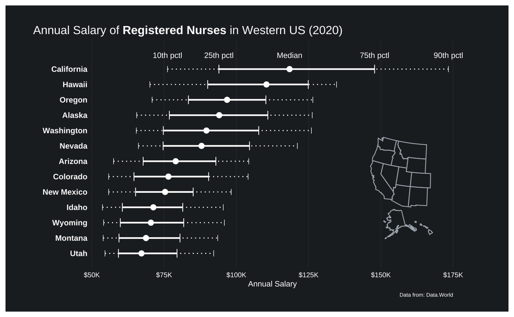

```r
p3 | inset_element(p4, align_to = "full", clip=F, on_top=T, ignore_tag = T,
                   left =0.57, bottom=.2, right=1, top=.6)
```

### Midwest region: median annual salary

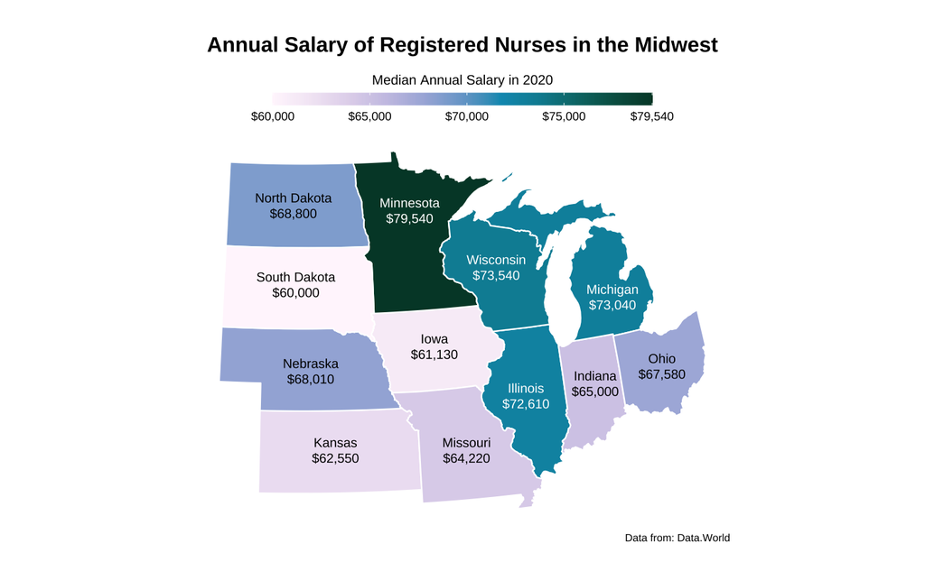

```r
plot_usmap(data=df20, values="annual_salary_median", include=.midwest_region, color="white") +
  scale_fill_continuous_sequential(palette="PuBuGn", breaks=c(60000, 65000, 70000,75000,79540),label=dollar_format()) +
  theme_void(base_size = 8.5) +
  theme(plot.margin = unit(c(.75, 1, .55, 1), "cm"),
        legend.title=element_text(size=7.7),
        plot.title=element_markdown(size=12,hjust=.5, margin=margin(b=10)),
        plot.caption = element_text(size=6),
        legend.position = "top") +
  coord_fixed() +
  annotate(geom="richtext",label.color=NA, size=2.6,fill=NA,
           color=c("black","black","black","black","white","black","black","white","black","black","white","white"),
           x=c(-40000, -30000, 30000, 130000, 430000, 530000,660000,900000,1180000, 1450000, 1250000,780000),
           y=c(270000,-50000, -400000, -720000, 250000, -300000, -720000, -500000,-450000,-380000,-100000,20000),
           label=c("North Dakota<br>$68,800","South Dakota<br>$60,000","Nebraska<br>$68,010",
                   "Kansas<br>$62,550","Minnesota<br>$79,540","Iowa<br>$61,130",
                   "Missouri<br>$64,220", "Illinois<br>$72,610", "Indiana<br>$65,000",
                   "Ohio<br>$67,580","Michigan<br>$73,040","Wisconsin<br>$73,540")) +
  labs(title="**Annual Salary of Registered Nurses in the Midwest**",
       fill="Median Annual Salary in 2020", caption="Data from: Data.World") +
  guides(fill = guide_colorbar(title.position = "top",
                                title.hjust = .5,
                                barwidth = unit(15, "lines"),
                                barheight = unit(.5, "lines")))
```

### North east region: percentage change

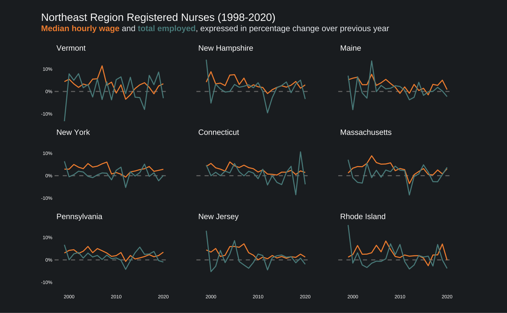

```r
# north east grid
northeast_grid2 = us_state_grid2 %>% filter(code %in% .northeast_region) %>%
  mutate(col = col-8,
         col=ifelse(row==1,col-1,col))

# percent change (wage and total emp)
nurses %>%
  filter(st %in% .northeast_region) %>%
  select(year,state,hourly_wage_median, total_employed_rn) %>%
  group_by(state) %>%
  arrange(year, .by_group=TRUE) %>%
  mutate("Hourly wage median"=(hourly_wage_median/lag(hourly_wage_median)-1),
         "Total employed RN"=(total_employed_rn/lag(total_employed_rn)-1)) %>%
  select(year, state, "Hourly wage median", "Total employed RN") %>%
  pivot_longer("Hourly wage median":"Total employed RN") %>%
  ggplot(aes(x=year, y=value, color=(name))) +
  geom_hline(yintercept=0, linetype="dashed", color="#747474") +
  geom_line(show.legend = F) +
  scale_y_continuous(labels=scales::percent) +
  scale_x_continuous(breaks=c(2000,2010,2020)) +
  facet_geo(~state, grid=northeast_grid2) +
  scale_color_manual(values=c("#f28f3b","#588b8b")) +
  #scale_color_manual(values=c("#ff8811","#eaf8bf")) +
  theme_gdocs(base_size = 5) +
  theme(panel.grid.major=element_blank(),
        axis.line.x=element_blank(),
        strip.text=element_text(size=8, color="white"),
        axis.text=element_text(color="white"),
        axis.title=element_blank(),
        plot.background = element_rect(fill="#212529", color=NA),
        plot.margin = unit(c(.5, 2, .5, 1.5), "cm"),
        panel.spacing.x = unit(2, "lines"),
        plot.title.position="plot",
        plot.title=element_text(color="white", size=11),
        plot.subtitle=element_markdown(color="#e9ecef", size=8.5),
        ) +
  labs(title="Northeast Region Registered Nurses (1998-2020)",
       subtitle= "<span style = 'color:#f28f3b;'><b>Median hourly wage<b></span> and <span style = 'color:#588b8b;'><b>total employed<b></span>, expressed in percentage change over previous year<br>")
```

```r
NA
```

### Southern region: hourly wage

```r
library(ggfan)
```

```r
south_grid2 = us_state_grid2 %>% filter(code %in% .south_region) %>%
  mutate(col=col-3, row=row-3)
```

```r
fan = nurses %>%
  mutate(st=ifelse(state=="District of Columbia","DC",st)) %>%
  filter(st %in% .south_region) %>%
  select(state, year, hourly_wage_median, contains("hourly") & contains("percentile")) %>%
  rename("percentile_0" = "hourly_wage_median") %>%
  pivot_longer(contains("perc")) %>%
  mutate(percentile = parse_number(name) / 100)
```

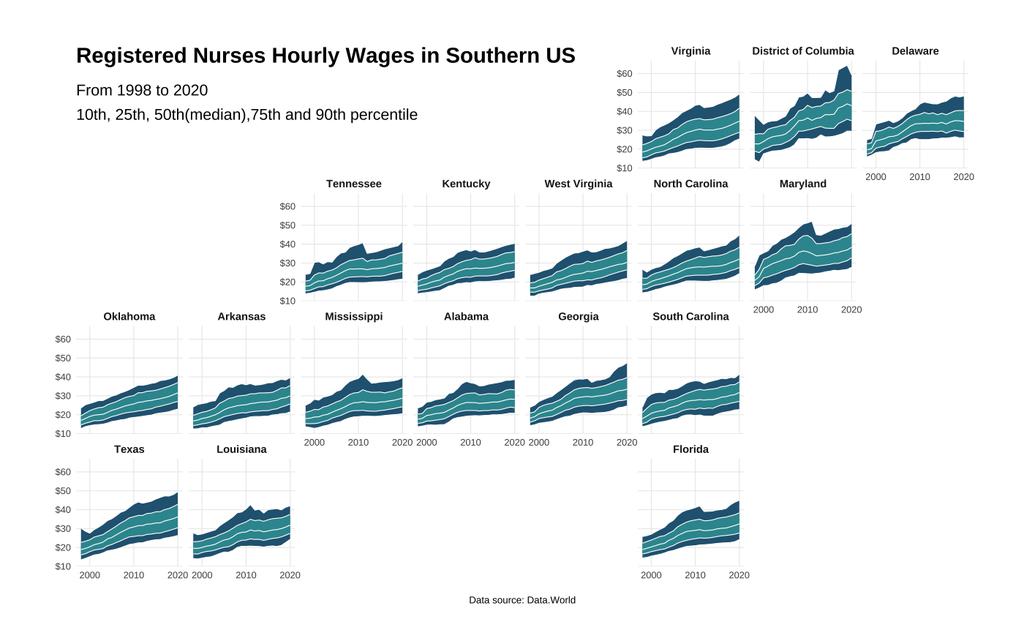

```r
ggplot(fan, aes(x = year, y = value, quantile = percentile)) +
  geom_fan() +
  geom_line(aes(group = percentile), size = 0.2, color = "white") +
  scale_x_continuous(breaks = c(2000, 2010, 2020)) +
  scale_y_continuous(labels=dollar_format()) +
  scale_fill_stepsn(colors = c("#38a3a5", "#22577a")) +
  facet_geo(~state, grid=south_grid2) +
  theme_minimal(base_size = 6, base_family = "Arial Narrow") +
  theme(legend.position = "none",
        strip.text=element_text(size=5.5, face="bold", family="Arial Narrow"),
        panel.grid.minor=element_blank(),
        axis.title=element_blank(),
        panel.grid=element_line(size=.2),
        plot.margin = unit(c(-.5, 1, .5, 1), "cm"),
        plot.title = element_text(vjust = - 16, size=11, face="bold"),
        plot.subtitle = element_text(vjust = - 26, size=8, lineheight = 1.3),
        plot.caption=element_text(hjust=.5, size=5)
        ) +
  labs(title="Registered Nurses Hourly Wages in Southern US",
       subtitle="From 1998 to 2020\n10th, 25th, 50th(median),75th and 90th percentile",
       caption="\nData source: Data.World")
```